# Prosper Loan Data Exploration

## Preliminary Wrangling

> This document explores the Prosper Loan data set which contains 81 columns of data on ~114,000 loan applications

```python
# import all packages and set plots to be embedded inline
import numpy as np
import pandas as pd
import matplotlib.pyplot as plt
import seaborn as sns
import warnings
warnings.filterwarnings("ignore", category=DeprecationWarning)
warnings.filterwarnings("ignore", category=FutureWarning)

%matplotlib inline
```

> Load in your dataset and describe its properties through the questions below. Try and motivate your exploration goals through this section.

```python
# Load in prosper loan data set
loans = pd.read_csv('prosperLoanData.csv')
```

```python
# high-level look at what dataset contains
print(loans.shape)
print(loans.info())
print(loans.head())
```

```
(113937, 81)
<class 'pandas.core.frame.DataFrame'>
RangeIndex: 113937 entries, 0 to 113936
Data columns (total 81 columns):
ListingKey                             113937 non-null object
ListingNumber                          113937 non-null int64
ListingCreationDate                    113937 non-null object
CreditGrade                            28953 non-null object
Term                                   113937 non-null int64
LoanStatus                             113937 non-null object
ClosedDate                             55089 non-null object
BorrowerAPR                            113912 non-null float64
BorrowerRate                           113937 non-null float64
LenderYield                            113937 non-null float64
EstimatedEffectiveYield                84853 non-null float64
EstimatedLoss                          84853 non-null float64
EstimatedReturn                        84853 non-null float64
ProsperRating (numeric)                84853 non-null float64
ProsperRating (Alpha)                  84853 non-null object
ProsperScore                           84853 non-null float64
ListingCategory (numeric)              113937 non-null int64
BorrowerState                          108422 non-null object
Occupation                             110349 non-null object
EmploymentStatus                       111682 non-null object
EmploymentStatusDuration               106312 non-null float64
IsBorrowerHomeowner                    113937 non-null bool
CurrentlyInGroup                       113937 non-null bool
GroupKey                               13341 non-null object
DateCreditPulled                       113937 non-null object
CreditScoreRangeLower                  113346 non-null float64
CreditScoreRangeUpper                  113346 non-null float64
FirstRecordedCreditLine                113240 non-null object
CurrentCreditLines                     106333 non-null float64
OpenCreditLines                        106333 non-null float64
TotalCreditLinespast7years             113240 non-null float64
OpenRevolvingAccounts                  113937 non-null int64
OpenRevolvingMonthlyPayment            113937 non-null float64
InquiriesLast6Months                   113240 non-null float64
TotalInquiries                         112778 non-null float64
CurrentDelinquencies                   113240 non-null float64
```

[output cut: 76 more lines]

```
   PercentFunded  Recommendations InvestmentFromFriendsCount  \
0            1.0                0                          0
1            1.0                0                          0
2            1.0                0                          0
3            1.0                0                          0
4            1.0                0                          0

  InvestmentFromFriendsAmount Investors
0                         0.0       258
1                         0.0         1
2                         0.0        41
3                         0.0       158
4                         0.0        20

[5 rows x 81 columns]
```

```python
# Remove Null values from object data types
objects = loans.select_dtypes(include=['object']).columns.values
loans[objects] = loans[objects].fillna('Unknown')

loans.select_dtypes(exclude=[np.number]).isnull().sum()
```

```
ListingKey                 0
ListingCreationDate        0
CreditGrade                0
LoanStatus                 0
ClosedDate                 0
ProsperRating (Alpha)      0
BorrowerState              0
Occupation                 0
EmploymentStatus           0
IsBorrowerHomeowner        0
CurrentlyInGroup           0
GroupKey                   0
DateCreditPulled           0
FirstRecordedCreditLine    0
IncomeRange                0
IncomeVerifiable           0
LoanKey                    0
LoanOriginationDate        0
LoanOriginationQuarter     0
MemberKey                  0
dtype: int64
```

```python
# Need to find values for the float64 dtypes or we will lose close to half are data. Lets work through these 1 by 1
# EstimatedEffectiveYeild = BorrowerRate - EstimatedLossFromFees
estimated_loss_from_fees = loans['BorrowerRate'] - loans['EstimatedEffectiveYield']
loans['EstimatedEffectiveYield'].fillna(loans['BorrowerRate'] - estimated_loss_from_fees.median(), inplace=True)
loans['EstimatedEffectiveYield'].isnull().sum()
```

```
0
```

```python
# EstimatedLoss is the estimated pricipal loss on chargeoffs, not a good way to calculate, lets just take the median value.
loans['EstimatedLoss'].fillna(loans['EstimatedLoss'].median(), inplace=True)
loans['EstimatedLoss'].isnull().sum()
```

```
0
```

```python
# EstimatedReturn is the difference between Estimated Effective Yiueld and Estimated Loss Rate
loans['EstimatedReturn'].fillna(loans['EstimatedEffectiveYield'] - loans['EstimatedLoss'], inplace=True)
loans['EstimatedReturn'].isnull().sum()
```

```
0
```

```python
# ProsperRating (numeric) is assigned at the time of loan listing, since we can't calculate, we will just use the median
loans['ProsperRating (numeric)'].fillna(loans['ProsperRating (numeric)'].median(), inplace=True)
loans['ProsperRating (numeric)'].isnull().sum()
```

```
0
```

```python
# ProsperScore is assigned using historic prosper data, since we can't calculate, we will just use the median
loans['ProsperScore'].fillna(loans['ProsperScore'].median(), inplace=True)
loans['ProsperScore'].isnull().sum()
```

```
0
```

```python
# BorrowerAPR is missing 25 values, BorrowerAPR = BorrowerRate + BorrowerFees Lets find the median fees and add it to the BorrowerRate
loans['BorrowerAPR'].fillna(loans['BorrowerRate'] + (loans['BorrowerAPR'] - loans['BorrowerRate']).median(), inplace=True)
loans['BorrowerAPR'].isnull().sum()
```

```
0
```

```python
# The majority of the remaining fields aren't of any real interest to my exploration, I will clean up a few fields by droping
# there missing rows.
loans.dropna(subset=['EmploymentStatusDuration', 'CurrentCreditLines', 'OpenCreditLines', 'AmountDelinquent',
                     'CreditScoreRangeLower', 'FirstRecordedCreditLine', 'TotalCreditLinespast7years'], inplace=True)
```

```python
print(loans.shape)
print(loans.info())
print(loans.head())
```

```
(106290, 81)
<class 'pandas.core.frame.DataFrame'>
Int64Index: 106290 entries, 0 to 113936
Data columns (total 81 columns):
ListingKey                             106290 non-null object
ListingNumber                          106290 non-null int64
ListingCreationDate                    106290 non-null object
CreditGrade                            106290 non-null object
Term                                   106290 non-null int64
LoanStatus                             106290 non-null object
ClosedDate                             106290 non-null object
BorrowerAPR                            106290 non-null float64
BorrowerRate                           106290 non-null float64
LenderYield                            106290 non-null float64
EstimatedEffectiveYield                106290 non-null float64
EstimatedLoss                          106290 non-null float64
EstimatedReturn                        106290 non-null float64
ProsperRating (numeric)                106290 non-null float64
ProsperRating (Alpha)                  106290 non-null object
ProsperScore                           106290 non-null float64
ListingCategory (numeric)              106290 non-null int64
BorrowerState                          106290 non-null object
Occupation                             106290 non-null object
EmploymentStatus                       106290 non-null object
EmploymentStatusDuration               106290 non-null float64
IsBorrowerHomeowner                    106290 non-null bool
CurrentlyInGroup                       106290 non-null bool
GroupKey                               106290 non-null object
DateCreditPulled                       106290 non-null object
CreditScoreRangeLower                  106290 non-null float64
CreditScoreRangeUpper                  106290 non-null float64
FirstRecordedCreditLine                106290 non-null object
CurrentCreditLines                     106290 non-null float64
OpenCreditLines                        106290 non-null float64
TotalCreditLinespast7years             106290 non-null float64
OpenRevolvingAccounts                  106290 non-null int64
OpenRevolvingMonthlyPayment            106290 non-null float64
InquiriesLast6Months                   106290 non-null float64
TotalInquiries                         106290 non-null float64
CurrentDelinquencies                   106290 non-null float64
```

[output cut: 76 more lines]

```
   PercentFunded  Recommendations InvestmentFromFriendsCount  \
0            1.0                0                          0
1            1.0                0                          0
3            1.0                0                          0
4            1.0                0                          0
5            1.0                0                          0

  InvestmentFromFriendsAmount Investors
0                         0.0       258
1                         0.0         1
3                         0.0       158
4                         0.0        20
5                         0.0         1

[5 rows x 81 columns]
```

### What is the structure of your dataset?

> Original (113937, 81) after modification (106290, 81)

### What is/are the main feature(s) of interest in your dataset?

> Some of the features I am interested with this dataset is LoanStatus, How many of the loans get completed

### What features in the dataset do you think will help support your investigation into your feature(s) of interest?

> Features in this data set that would help me to investigate the loan status would be; ListingCategory, ProsperScore, BorrowerAPR, Term, LoanOriginalAmount, BorrowerState, Occupation, EmployementStatus just to name a few

## Univariate Exploration

> Lets first look at the main feature we are interested in LoanStatus

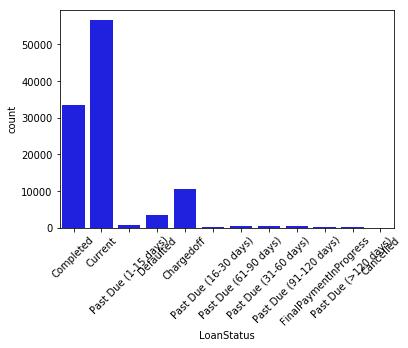

```python
g = sns.countplot(loans['LoanStatus'], color='blue')
plt.xticks(rotation=45);
```

> This plot is still hard to read since we have a lot of categories with only a few counts in each. Lets take a look at wether the loan was Completed, ChargedOff, Current, or in some state of Default

```python
loans['newLoanStatus'] = ['Defaulted' if 'Past' in x else x for x in loans['LoanStatus']]
```

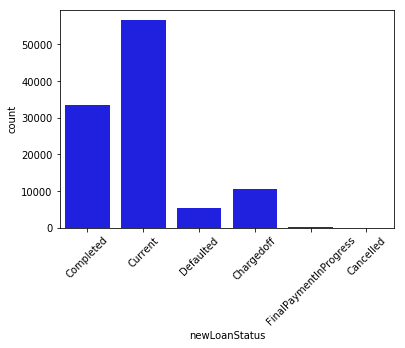

```python
g = sns.countplot(loans['newLoanStatus'], color='blue')
plt.xticks(rotation=45);
```

> Here we can better see that the majority of loans are still current, or complete, with a same portion of them in default or charged off status. Now lets take a look at the Listing Category, why do people take out loans.

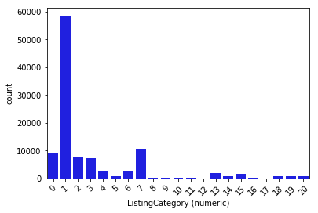

```python
g = sns.countplot(loans['ListingCategory (numeric)'], color='blue')
plt.xticks(rotation=45);
```

> Well this doesn't tell us much at all. Lets go ahead and create a dictionary for the values 0 - 20 and then convert this column to a object vs an int

```python
listingdic = {0:'Not Available', 1: 'Debt Consolidation', 2: 'Home Improvement', 3: 'Business', 4: 'Personal Loan',
              5: 'Student Use', 6: 'Auto', 7: 'Other', 8: 'Baby&Adoption', 9: 'Boat', 10: 'Cosmetic Procedure', 11: 'Engagement Ring',
              12: 'Green Loans', 13: 'Household Expenses', 14: 'Large Purchases', 15: 'Medical/Dental', 16: 'Motorcycle',
              17: 'RV', 18: 'Taxes', 19: 'Vacation', 20: 'Wedding Loans'}

loans.replace({'ListingCategory (numeric)': listingdic}, inplace=True)
## Don't need the old Column Name of ListingCategory (numeric), lets Change it to ListingCategory
loans.rename(columns={'ListingCategory (numeric)':'ListingCategory'}, inplace=True)
```

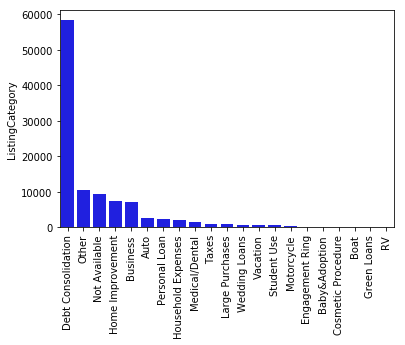

```python
g = sns.barplot(x=loans.ListingCategory.value_counts().index, y=loans.ListingCategory.value_counts(), color='blue')
plt.xticks(rotation=90);
```

> It's very interesting that the majority of the loans are being taking out for Debt Consolidation, with the next top two categories having no info (other, Not Available) to tell you what they are about. Next lets look at how prosper is ranking the applicants as with regards to their ability to pay. 10 is the best score (lowest risk) while 1 is the worst (highest risk)

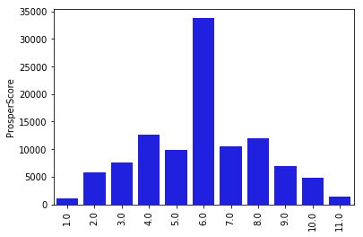

```python
g = sns.barplot(x=loans.ProsperScore.value_counts().index, y=loans.ProsperScore.value_counts(), color='blue')
plt.xticks(rotation=90);
```

> Well the fact that we have a few 11's is intersting as this was a 1-10 rating. However, overall it has a nice bell shape with a strong peak right in the middle. Next Lets Look at what kind of APR customers are receiving.

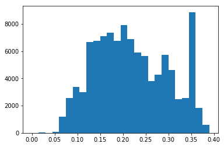

```python
h = plt.hist(loans['BorrowerAPR'], bins=np.arange(0,.4,.015))
```

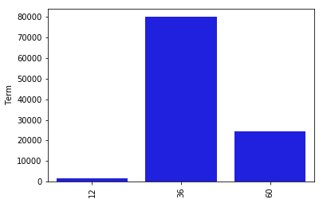

```python
g = sns.barplot(x=loans.Term.value_counts().index, y=loans.Term.value_counts(), color='blue')
plt.xticks(rotation=90);
```

> Here we can see that the majority of loan terms are for 36 months. A few are longer term at 60 and very little at 12 months. Next lets look at where these loans originate from.

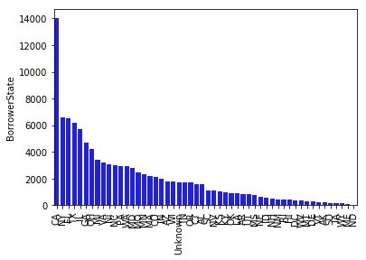

```python
s = sns.barplot(x=loans.BorrowerState.value_counts().index, y=loans.BorrowerState.value_counts(), color='blue')
plt.xticks(rotation=90);
```

> Looks like we are getting all fifty states, the District of Columbia and an Unknown source, maybe PurtoRico. California takes a significant chuck, I'd suspect that it was because of the population of CA. Would be interesting to look at Loans as a percentage of the population. Next lets see if we can see any trends in Occupation

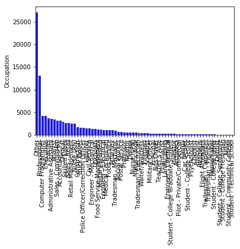

```python
o = sns.barplot(x=loans.Occupation.value_counts().index, y=loans.Occupation.value_counts(), color='blue')
plt.xticks(rotation=90);
```

> Well this chart doesn't give us a lot of information. The primary categories are Other and Professional and then everything else. This won't be useful to us. Lets look at the percentage of people who got loans were employed.

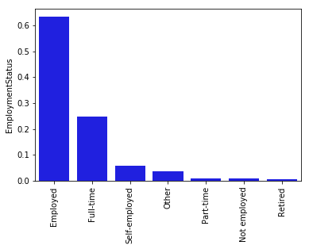

```python
o = sns.barplot(x=loans.EmploymentStatus.value_counts().index, y=loans.EmploymentStatus.value_counts()/loans['EmploymentStatus'].shape[0], color='blue')
plt.xticks(rotation=90);
```

> This doesn't give us a ton of information, The category of Employed consists of 60% of all records, while still having categories of Full-time, self, part-time which are all categories of being employed. Not sure this will be of much use to us. Lets look at how much the loans are taken out for.

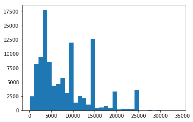

```python
la = plt.hist(loans['LoanOriginalAmount'], bins=np.arange(100,35000,1000))
```

> This is an interesting chart, the chart is right skewed, with several peaks where loans are given at what I'd consider to be normal increments. (10k, 15k, 20k, ect)

### Discuss the distribution(s) of your variable(s) of interest. Were there any unusual points? Did you need to perform any transformations?

> See has how my primary variable of interest was if loan holders paid their loans back, its hard to determine its distribution. No transformations were needed

## Bivariate Exploration

> In this section, investigate relationships between pairs of variables in your data. Make sure the variables that you cover here have been introduced in some fashion in the previous section (univariate exploration). Since I am interested in weather loans defalut or not, lets clean up the data a bit more and have a binary category for Loanstatus

```python
# Create a new df with loans that aren't current.
loans_default = loans[loans['LoanStatus'] != 'Completed']
loans_default = loans_default[loans_default['LoanStatus'] != 'FinalPaymentInProgress']
loans_default['LoanStatus'].value_counts()
```

```
Current                   56566
Chargedoff                10632
Defaulted                  3289
Past Due (1-15 days)        806
Past Due (31-60 days)       363
Past Due (61-90 days)       313
Past Due (91-120 days)      304
Past Due (16-30 days)       265
Past Due (>120 days)         16
Cancelled                     1
Name: LoanStatus, dtype: int64
```

```python
# Change all Current as 1 and anything else as 0
loans_default['LoanStatus'] = (loans_default['LoanStatus'] == "Current").astype(int)
loans_default.LoanStatus.unique()
```

```
array([1, 0], dtype=int64)
```

> Now we can start to explore the data on who is more likely to default on their loans or not, lets look at States

```python
loans_default['LoanStatus'].mean(), 1-loans_default['LoanStatus'].mean()
```

```
(0.7796292467783061, 0.22037075322169386)
```

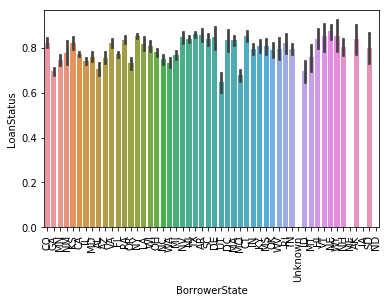

```python
sns.barplot(x="BorrowerState", y="LoanStatus", data=loans_default)
plt.xticks(rotation=90);
```

> Something strang is going on with Unknown, ME, IA and ND Lets see if we can see anything.

```python
unk, me, ia, nd = loans_default[loans_default["BorrowerState"] == "Unknown"], \
loans_default[loans_default["BorrowerState"] == "ME"], loans_default[loans_default["BorrowerState"] == "IA"], \
loans_default[loans_default["BorrowerState"] == "ND"]
1 - unk["LoanStatus"].mean(), 1 - me["LoanStatus"].mean(), 1 - ia["LoanStatus"].mean(), 1 - nd["LoanStatus"].mean()
```

```
(1.0, 1.0, 1.0, 1.0)
```

> Looks like all 4 of those values have default rates of 100%, lets look at how many values we are talkabout about.

```python
loans_default['BorrowerState'].value_counts()
```

```
CA         9332
NY         4745
TX         4621
FL         4519
IL         3770
GA         3045
OH         2949
NJ         2290
MI         2281
VA         2173
PA         2164
NC         2031
MD         1915
WA         1827
MO         1609
MN         1511
MA         1501
CO         1406
IN         1368
WI         1250
TN         1230
AZ         1225
CT         1194
AL         1125
OR         1057
NV          846
SC          823
KY          726
KS          725
LA          709
AR          651
OK          624
Unknown     593
MS          588
NE          463
UT          444
NH          389
ID          370
RI          334
NM          303
HI          294
WV          255
DC          235
DE          224
MT          193
SD          149
VT          148
AK          123
WY          102
IA           58
ME           35
ND           13
Name: BorrowerState, dtype: int64
```

> The states (ME, IA, ND) all have low counts <60, however, the category Unknown has almost 600 values, which are all considered to be in default. Lets look at the reason for the loans and default next.

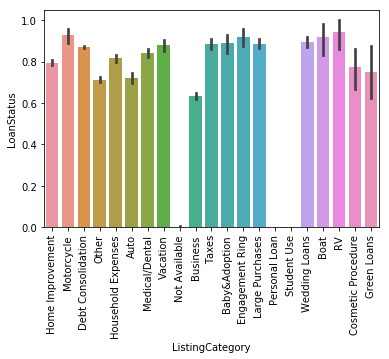

```python
sns.barplot(x='ListingCategory', y='LoanStatus', data=loans_default)
plt.xticks(rotation=90);
```

> Again we have several categories of loans being in 100% default for the categories (Not Available, Personal Loan, and Student Use) Again we are only looking at Loans that haven't been completed, just loans that are current or in a default status. Lets look at how loan default was determined by Prospers Score

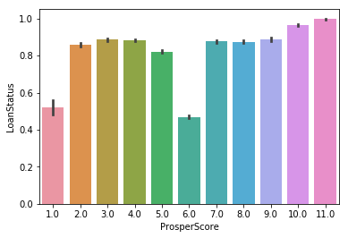

```python
sns.barplot(x='ProsperScore', y='LoanStatus', data=loans_default);
```

> I find this chart very interesting, we saw in the previous chart on ProsperScore that we had the majority of loans going to people who got a score of 6. Which would lead you to believe that those loans were a better bet, however, it looks to be the opposite, with 6 and 1 brining in scores of ~50% default and everyone else easily above 80%. How do defaults rates compare with Employment Status

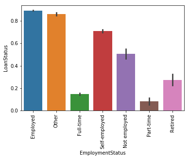

```python
sns.barplot(x='EmploymentStatus', y='LoanStatus', data=loans_default)
plt.xticks(rotation=90);
```

> EmploymentStatus seems to have a very interesting relationship on default, with Full-Time and Part-Time status defaulting more often then Unemployed and the retired. Lets look at the term length next

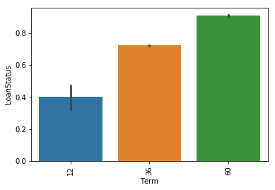

```python
sns.barplot(x='Term', y='LoanStatus', data=loans_default)
plt.xticks(rotation=90);
```

> Here we can see that longer term loans seem to be in default less then loans of shorter durations. Lets look at how loan amount and default are related as well as BorrowerAPR and default are related.

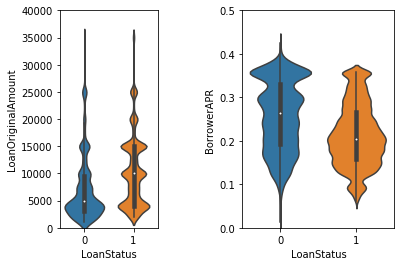

```python
fig = plt.figure()
ax1 = fig.add_subplot(131)
sns.violinplot(x='LoanStatus', y='LoanOriginalAmount', data=loans_default).set_ylim([0,40000])

ax2 = fig.add_subplot(122)
sns.violinplot(x='LoanStatus', y='BorrowerAPR', data=loans_default).set_ylim([0,.50]);
```

> Looking here it appears that the majority of loans that defaulted were for small amounts, 5000 or less and the borrowers who had a higher APR tended to default more often then those that had a lower APR

### Talk about some of the relationships you observed in this part of the investigation. How did the feature(s) of interest vary with other features in the dataset?

> I believe a lot of relationships come out that you would expect. High APR loans tended to default more often then loans that had a more "resonable" APR. Loans that were for larger values, tended to not be in default more then the smaller loans. I would think this was because larger loans have a better applicant (higher income, credit score, ect) then maybe the smaller loans. Some things I found intersting were, All the states listed as Unknown defaulted on there loans. Why? Applicants that listed full-time and part-time employment default more often then retired and unemployed applicants.

## Multivariate Exploration

> Lets create some graphs looking at multiple variables. First lets look at LoanAmount, BorrowerAPR and DefaultStatus

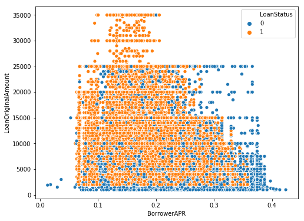

```python
plt.figure(figsize = [8,6])
sns.scatterplot(x='BorrowerAPR', y='LoanOriginalAmount', hue='LoanStatus', data=loans_default);
```

> Well there is no linear correlation to this data, however, we can see that the majority of the loans about 30% APR end in default, that the majority of loans >25k are Current and really low loan amounts all seem to end in default. Next Lets look at ProsperScore, LoanAmount and Default

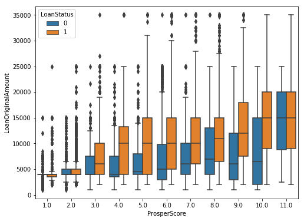

```python
plt.figure(figsize = [8,6])
sns.boxplot(x='ProsperScore', y='LoanOriginalAmount', data=loans_default, hue='LoanStatus');
```

> Here we can see a greater percentage of people tend to default with low loan amounts and lower scores tend to get lower amounts. Lets look at how the same applies to BorrowerAPR

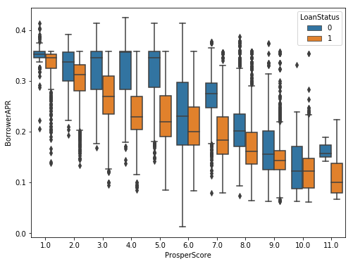

```python
plt.figure(figsize = [8,6])
sns.boxplot(x='ProsperScore', y='BorrowerAPR', data=loans_default, hue='LoanStatus');
```

> Whats interesting on this graph is that its sloped in the opposite direction of the ProsperScore and Amount. Again showing, that Better scores get a better rate and lower scores get a higher rate. Lets now look at LoanAmount, Category and default

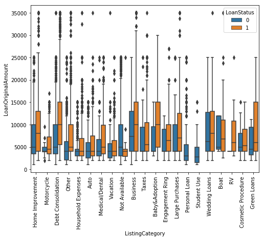

```python
plt.figure(figsize = [8,6])
sns.boxplot(x='ListingCategory', y='LoanOriginalAmount', data=loans_default, hue='LoanStatus')
plt.xticks(rotation=90);
```

> Here we can see what categories got a larger amount of funding and if they defaulted or not. Several of the categories (Engagement Rings, Large Purchases, Business Loans) had a wide range of loan amounts and pretty equal amount of defaults vs currents. Some categories (RV, Motorcycle) had really low default ranges compared to the current loan amount ranges. Then we have categories like Student Loans, Personal Loans that have no sign of current status, showing they almost always default. A recent chart I have found fun to make and shows some curious relationships is a Sankey Diagram. We will need to do some work with the data to get it in the format needed to work with it.

```python
# Lets create two new dataframes by grouping some categories together and finding the counts in each. This will be used later
# to create the chart.
df1 = loans_default.groupby(['ProsperScore', 'LoanStatus']).size().reset_index(name='counts')
df2 = loans_default.groupby(['LoanStatus', 'ListingCategory']).size().reset_index(name='counts')
```

```python
# Now we need to create an empty list that we can fill with some dictionaries, and a dict of colors for the different categories.
# Then we can loop through the dataframes we created eariler adding them to the links list as dicts.
links = []
colors = {'Cur': 'steelblue', 'Def':'indianred', 1:'maroon', 2:'darkred', 3:'red', 4:'gold', 5:'olive', 6:'yellow', 7:'lime', 8:'limegreen', 9:'forestgreen', 10:'green', 11:'darkgreen'}
for index, row in df1.iterrows():
    if row['LoanStatus'] == 1:
        links.append({'source': row['ProsperScore'], 'target': 'Cur', 'value': row['counts'], 'color':colors[row['ProsperScore']]})
    else:
        links.append({'source': row['ProsperScore'], 'target': 'Def', 'value': row['counts'], 'color':colors[row['ProsperScore']]})


for index, row in df2.iterrows():
    if row['LoanStatus'] == 1:
        links.append({'source': 'Cur', 'target': row['ListingCategory'], 'value': row['counts'], 'color':colors['Cur']})
    else:
        links.append({'source': 'Def', 'target': row['ListingCategory'], 'value': row['counts'], 'color':colors['Def']})
```

```python
# Create the Sankey Diagram, order defines the sort order, groups helps to identify which column is being ploted
from ipysankeywidget import SankeyWidget
from ipywidgets import Layout

layout = Layout(width="1000", height="1200")
def sankey(margin_top=10, **value):
    """Show SankeyWidget with default values for size and margins"""
    return SankeyWidget(layout=layout,
                        margins=dict(top=margin_top, bottom=0, left=20, right=100),
                        **value)
order = [[1, 2, 3, 4, 5, 6, 7, 8, 9, 10, 11], ['Cur', 'Def'], loans_default.ListingCategory.tolist()]
groups = [{'id': 'A', 'title': 'ProsperScore', 'nodes': loans_default.ProsperScore.tolist()},
         {'id': 'B', 'title': 'LoanStatus', 'nodes': ['Cur', 'Def']},
         {'id': 'C', 'title': 'ListingCategory', 'nodes': loans_default.ListingCategory.tolist()}]
sankey(links=links, order=order, linkLabelFormat='.1f', groups=groups).auto_save_png('sankey.png')
```

```python
%%html
<img src="sankey.png" />
```

[figure not shown]

> I feel this charts helps show the relationship between scores and if the loans default or are current, then it takes the loanstatus and shows what quantities of the defaulted loans fall into each of the categories. Her we can see that Loans with a ProsperScore of 6, make up the majority of the defaults, with approx. equal numbers from the rest of the categories. Then if we look at for what reason the loans defaulted we can see that the majority are for debt consolidation.

### Were there any interesting or surprising interactions between features?

> No interactions I saw.

> At the end of your report, make sure that you export the notebook as an html file from the `File > Download as... > HTML` menu. Make sure you keep track of where the exported file goes, so you can put it in the same folder as this notebook for project submission. Also, make sure you remove all of the quote-formatted guide notes like this one before you finish your report!